# Ford GoBike System Data

## by Rana Samir

- Introduction
- Data Assessing
- Data Cleaning
- Data Visualization
  - Univariate Exploration
  - Bivariate Exploration
  - Multivariate Exploration

## Introduction

This data answers questions like: Where do Citi Bikers ride? When do they ride? How far do they go? Which stations are most popular? What days of the week are most rides taken on? This data exploration help you discover the answers to these questions and more.

This data is provided according to the NYCBS Data Use Policy.

> https://www.citibikenyc.com/system-data

```python
df = pd.read_csv("JC-202006-citibike-tripdata.csv")
df.head()
```

|  | tripduration | starttime | stoptime | start station id | start station name | start station latitude | start station longitude | end station id | end station name | end station latitude | end station longitude | bikeid | usertype | birth year | gender |
| --- | --- | --- | --- | --- | --- | --- | --- | --- | --- | --- | --- | --- | --- | --- | --- |
| 0 | 122 | 2020-06-01 00:02:21.7500 | 2020-06-01 00:04:24.3250 | 3792 | Columbus Dr at Exchange Pl | 40.716870 | -74.032810 | 3639 | Harborside | 40.719252 | -74.034234 | 42489 | Subscriber | 1987 | 1 |
| 1 | 1282 | 2020-06-01 00:12:27.1090 | 2020-06-01 00:33:50.0540 | 3198 | Heights Elevator | 40.748716 | -74.040443 | 3276 | Marin Light Rail | 40.714584 | -74.042817 | 42183 | Subscriber | 1988 | 1 |
| 2 | 186 | 2020-06-01 01:19:59.2090 | 2020-06-01 01:23:05.8930 | 3275 | Columbus Drive | 40.718355 | -74.038914 | 3681 | Grand St | 40.715178 | -74.037683 | 42140 | Subscriber | 1987 | 1 |
| 3 | 131 | 2020-06-01 01:26:42.2050 | 2020-06-01 01:28:53.8040 | 3267 | Morris Canal | 40.712419 | -74.038526 | 3681 | Grand St | 40.715178 | -74.037683 | 42120 | Subscriber | 1987 | 1 |
| 4 | 266 | 2020-06-01 01:27:33.7090 | 2020-06-01 01:32:00.1890 | 3639 | Harborside | 40.719252 | -74.034234 | 3186 | Grove St PATH | 40.719586 | -74.043117 | 42437 | Subscriber | 1972 | 2 |

# Data Visualization

### The structure of the dataset

> - Trip Duration (seconds)
> - Start Time and Date
> - Stop Time and Date
> - Start Station Name
> - End Station Name
> - Station ID
> - Station Latitude
> - Station Langituide
> - Bike ID
> - User Type (Customer = 24-hour pass or 3-day pass user; Subscriber = Annual Member)
> - Gender (Male, Female, unknown)
> - Year of Birth
> - Age
> - Distance (m)
> - Day ### Main features of interest in the dataset
> - Gender of users
> - Distance travelled by each user
> - Age of the users
> - User type
> - Trip duration ### Features in the dataset that will help support the investigation into the features of interest
> - The relationship between the age of users and thier type of th user. Also the type of the user and the trip duration. The Type of the user and the distance traveled. The trip duration and distance

## Univariate Exploration

> investigating distributions of individual variables, removing outliers, cleaning up and preparing for relationships between variables.

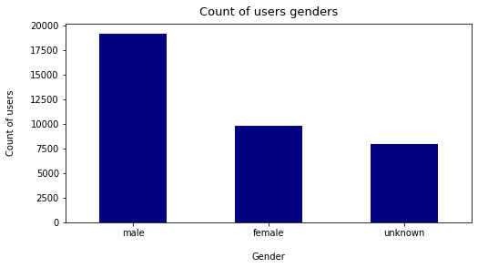

```python
trips['gender'].value_counts().plot(kind='bar', figsize=(8,4),color='navy')
plt.title('Count of users genders', fontsize=13, y=1.015)
plt.xlabel('Gender', labelpad=16)
plt.ylabel('Count of users', labelpad=16)
plt.xticks(rotation=360);
```

**Finding 1:** Males are the most users of the bike sharing system among genders

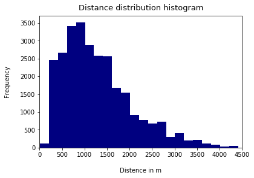

```python
bin_edges = np.arange(10, trips['distance(m)'].max()+10, 200)
plt.hist(data = trips, x = 'distance(m)', bins = bin_edges, color='navy');
plt.title('Distance distribution histogram', fontsize=13, y=1.015)
plt.xlim(0,4500);
plt.xlabel('Distence in m', labelpad=16)
plt.ylabel('Frequency', labelpad=16);
```

**Finding 2:** The mean traveled distance of each trip lies around 1000 meters. The distribution is right-skewed giving 75% of the trips is under 1500 metes suggesting that most of the ridders are not professional bike riders.

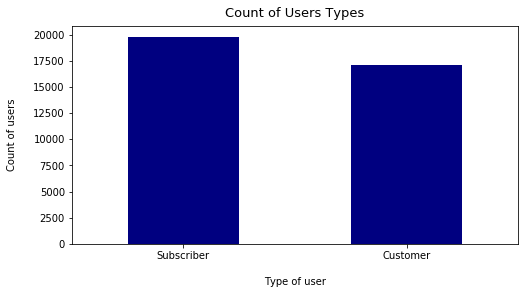

```python
trips['usertype'].value_counts().plot(kind='bar', figsize=(8,4),color='navy')
plt.title('Count of Users Types', fontsize=13, y=1.015)
plt.xlabel('Type of user', labelpad=16)
plt.ylabel('Count of users', labelpad=16)
plt.xticks(rotation=360);
```

**Finding 3:** More users are an annual subscribers of the system, however, the differenece between the casual users and the subscribers are not sever.

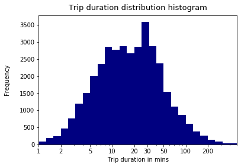

```python
log_binsize = 0.1
trips['Mins'] = trips['tripduration'] / 60
bins = 10 ** np.arange(0, np.log10(trips['Mins'].max())+log_binsize, log_binsize)
plt.hist(data = trips, x = 'Mins', bins = bins,color='navy');
plt.xscale('log');
plt.xlim(1,500);
plt.xticks([1, 2, 5, 10, 20,30, 50, 100, 200], [1, 2, 5, 10, 20, 30,50, 100, 200]);
plt.title('Trip duration distribution histogram', fontsize=13, y=1.015)
plt.ylabel('Frequency', labelpad=16)
plt.xlabel('Trip duration in mins');
```

**Finding 4:** The average trip duration lies between 10 to 50 min, which is a big interval to determine the pattern of users. The distribution is normally distributed giving a mean of around 40 min of each trip.

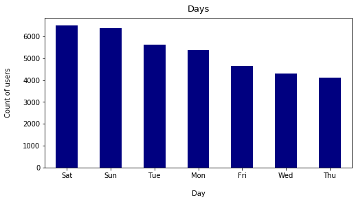

```python
trips['day'].value_counts().plot(kind='bar', figsize=(8,4),color='navy')
plt.title('Days', fontsize=13, y=1.015)
plt.xlabel('Day', labelpad=16)
plt.ylabel('Count of users', labelpad=16)
plt.xticks(rotation=360);
```

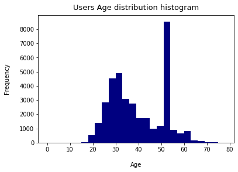

```python
bin_edges = np.arange(0, trips['age'].max()+1, 3)
plt.hist(data = trips, x = 'age', bins = bin_edges,color='navy');
plt.title('Users Age distribution histogram', fontsize=13, y=1.015)
plt.xlabel('Age', labelpad=16)
plt.ylabel('Frequency', labelpad=16);
```

**Finding 6:** The Average users age was observed to be between 25 and 35. However, there are a strike of users over the age of 50 resulting the mean users to lean over the right side of the distribution.

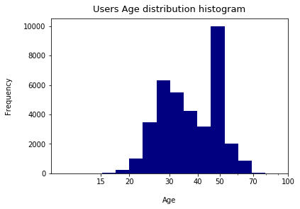

```python
log_binsize = 0.06
bins = 10 ** np.arange(1, np.log10(trips['age'].max())+log_binsize, log_binsize)
plt.hist(data = trips, x = 'age', bins = bins, color='navy');
plt.xscale('log');
plt.xticks([15, 20, 30, 40, 50, 70,100], [15,20, 30, 40, 50, 70,100]);
plt.title('Users Age distribution histogram', fontsize=13, y=1.015)
plt.xlabel('Age', labelpad=16)
plt.ylabel('Frequency', labelpad=16);
```

*This was a trial to change the scale of the distribution to a logaritmic scale, however, it leads the same observation as the linear scale.*

### The distribution(s) of variable(s) of interest, the unusual points and performed transformations

> The transofrmations was already done in the wranlging part, such as the distance travled by meters and the age of the customers. This results no further transormations in the data while the univaite exploration. Altough there was some manipulation in the scles and axes in the distributions due to outliares and non-normal distributions. Also, some points was unsual in the age data which was the strike of customers over 50 years in the age histogram.

## Bivariate Exploration

> investigating relationships between pairs of variables.

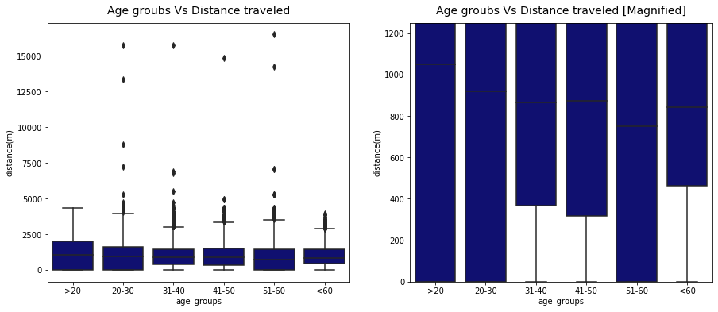

```python
size = (15, 6)
fig, ax = plt.subplots(1, 2,figsize=size)
sb.boxplot(data = trips, x = 'age_groups', y = 'distance(m)', color = 'navy',  ax=ax[0]);
sb.boxplot(data = trips, x = 'age_groups', y = 'distance(m)', color = 'navy',  ax=ax[1]);
ax[0].set_title('Age groubs Vs Distance traveled', fontsize=14, y=1.015)
ax[1].set_title('Age groubs Vs Distance traveled [Magnified]', fontsize=14, y=1.015)
ax[1].set_ylim(0,1250);
```

**Finding 7:** The mean distance traveled by users (from the magnified version) appears to be between 800 meter and 1100 which is relatively close. In general, they decrese as the age increases. So ages under 20 has the heighest mean followed by the other age groups expect for the group of sisties which breaks the patter and record an average close to the mid aged groups. Also, the overall graph shows that the age groups of twenties and fifties have an extrime outliers which will affect the final conculsion when calculating the average distance traveled by each group.

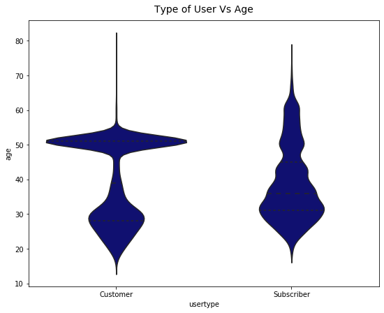

```python
size = (9, 7)
fig, ax = plt.subplots(figsize=size)
sb.violinplot(data = trips, x = 'usertype', y= 'age', color = 'navy' , inner = 'quartile')
ax.set_title('Type of User Vs Age', fontsize=14, y=1.015);
```

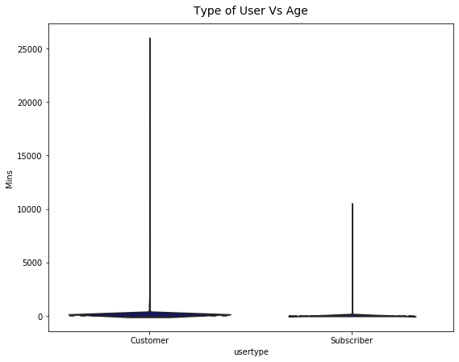

```python
size = (9, 7)
fig, ax = plt.subplots(figsize=size)
sb.violinplot(data = trips, x = 'usertype', y= 'Mins', color = 'navy' , inner = 'quartile')
ax.set_title('Type of User Vs Age', fontsize=14, y=1.015);
```

**Finding 9:** Customers riders are onger than subscribers

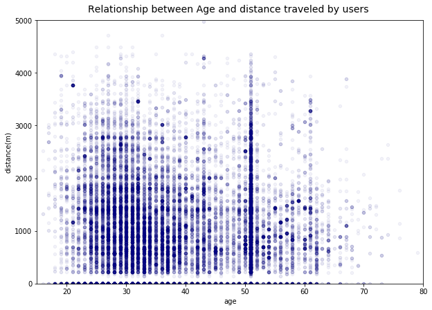

```python
size = (10, 7)
fig, ax = plt.subplots(figsize=size)
ax = plt.subplot(111)
trips.plot(x='age',y='distance(m)',ax=ax, kind='scatter', alpha = 1/20,color='navy')
ax.set_title('Relationship between Age and distance traveled by users ', fontsize=14, y=1.015)
ax.set_xlim(15,80)
ax.set_ylim(0,5000);
```

**Finding 10:** The relationship is not obvious as there are not clear overplotting in the graph whixh I tried to hundle as much as posssible. The grpah indicates a clustring in users over the age of 50

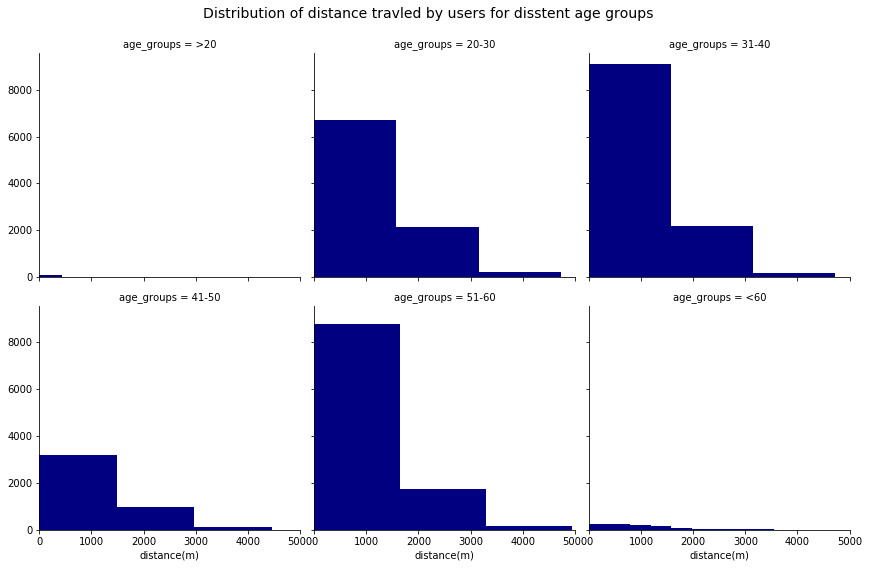

```python
d = {'color': ['navy']}
g = sb.FacetGrid(data = trips, col = 'age_groups', col_wrap = 3, height=4, aspect=1,  hue_kws=d)
g.map(plt.hist, "distance(m)")
g.set(xlim=(0, 5000))
g.fig.suptitle('Distribution of distance travled by users for disstent age groups', size = 14)
g.fig.subplots_adjust(top=0.9);
```

**Finding 11:** The distributions shows that overall traveled distance are at the peak with people in 30s and 50s. Also, it's least with people younger than 20. Which most probably affected by the number of users in every group affecting the overall result of distance traveled by each group.

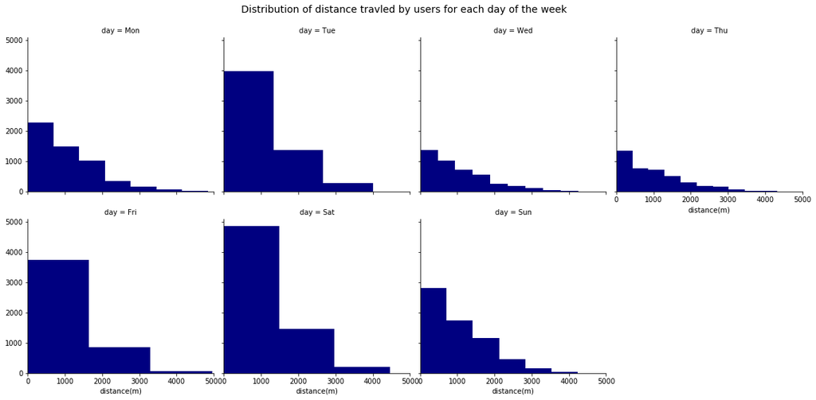

```python
g = sb.FacetGrid(data = trips, col = 'day', col_wrap = 4, height=4, aspect=1, hue_kws=d)
g.map(plt.hist, 'distance(m)');
g.set(xlim=(0, 5000))
g.fig.suptitle('Distribution of distance travled by users for each day of the week', size = 14)
g.fig.subplots_adjust(top=0.9);
```

**Finding 12:** The distributions shows that overall traveled distance are at the peak on Saturday which is a weekend. Also, it's high at Tuesday and Friday followed by the rest of week days which have relativly low frequency. All The distributions are positivly skewed.

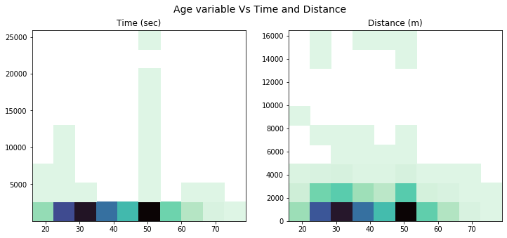

```python
fig, axs = plt.subplots(1, 2, figsize = [12,5])
g = axs[0].hist2d(data = trips, x = 'age', y = 'Mins', cmin = 0.5, cmap="mako_r")
h =axs[1].hist2d(data = trips, x = 'age', y = 'distance(m)', cmin = 0.5, cmap="mako_r")
fig.suptitle('Age variable Vs Time and Distance', size = 14)
axs[0].set_title('Time (sec)')
axs[1].set_title('Distance (m)');
```

**Finding 13:** It apperas that people around the age of 50 scores more distance and consequently more time in trips followed by users around the age of 30.

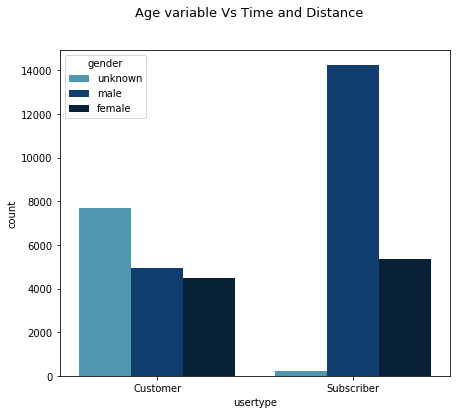

```python
fig, ax = plt.subplots(figsize=(7, 6))
sb.countplot(data = trips, x='usertype' ,hue = 'gender', palette="ocean_r")
fig.suptitle('Age variable Vs Time and Distance', size = 13);
```

**Finding 14:** The greatest number of subscribers are males with a notable diffrence from other categories. Females are the least dominant number of casual customers but the ratio between other categories are not big. So that the advertising of long term subscribtion should focus more on males and the casual users targeting should be more generic.

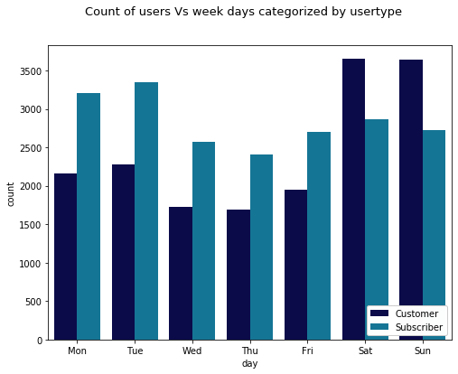

```python
size = (8,6)
fig, ax = plt.subplots(figsize= size)
ax = sb.countplot(data = trips, x='day' ,hue = 'usertype', palette="ocean")
ax.legend(loc = 4, ncol = 1, framealpha =3)
fig.suptitle('Count of users Vs week days categorized by usertype', size = 13);
```

**Finding 15:** The bar plot indicates that the number of causal customers increases in the weekends and decrease in the weekdays in comparsion to the subscribers number which is increasing in the weekdays and decrease in the weekends. This sugests that subscribers uses the system in thier daily life like work or school and the causal users uses the bike system for leisure or inconsistant trips.

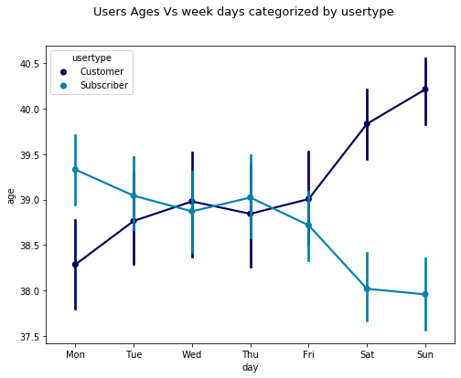

```python
fig, ax = plt.subplots(figsize=size)
sb.pointplot(data=trips, x='day', y='age', hue = 'usertype', scale=.8, palette="ocean")
fig.suptitle('Users Ages Vs week days categorized by usertype', size = 13);
```

**Finding 16:** The plot indicates that casual customers in elder age increase in the weekends and decrease in the weekdays. On the other hand the subscribers in younger age increase in weekday and decrease in weekends.

### Did you observe any interesting relationships between the other features (not the main feature(s) of interest)?

> The relationsship between the age and the distance travled and the trip duration was inconclusive and doesn't have a defint pattern. However, it was noticed that causal customers trips are longer than subscribers.

## Multivariate Exploration

> Createting plots of three or more variables to investigate the data even further.

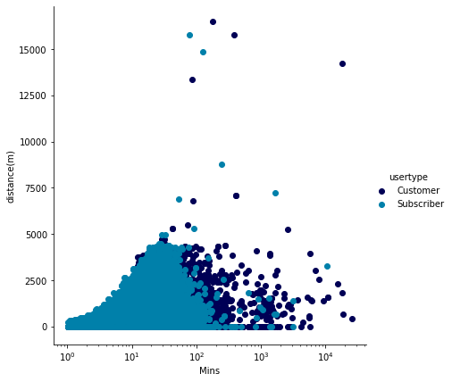

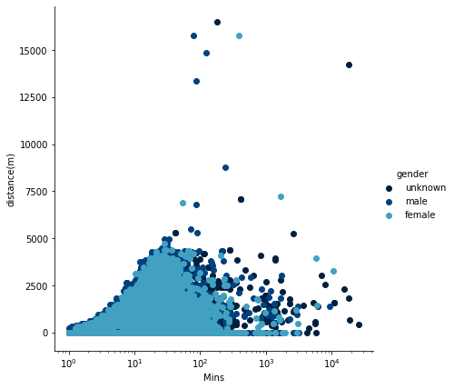

```python
k = sb.FacetGrid(data = trips, hue = 'usertype', height = 6, palette="ocean")
k.map(plt.scatter, 'Mins','distance(m)').add_legend()
k.set(xscale = 'log');

g = sb.FacetGrid(data = trips, hue = 'gender', height = 6, palette="ocean")
g.map(plt.scatter, 'Mins','distance(m)').add_legend()
g.set(xscale = 'log');
```

**Finding 17:** The scatter plot doesn't show an obvious corellation. However, we can deduce a positive coreelation from the begining to the mean of the trip duration which is 38 min , and a negative correlation the mean of 38 minfrom to maximum traveled duation. This deduction is applied to the different genders and the different user types.

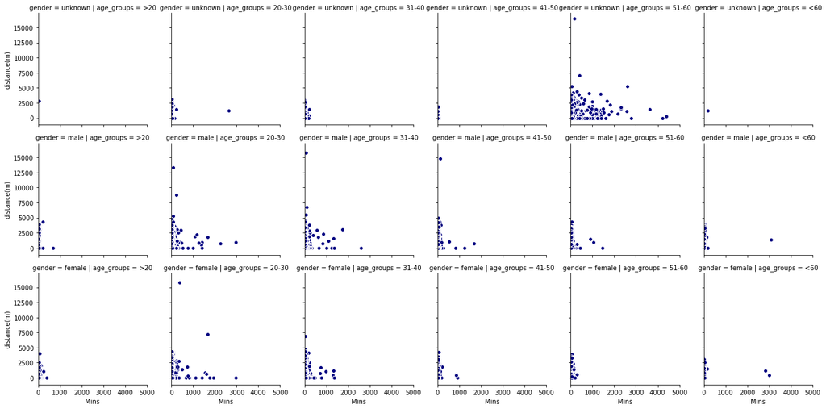

```python
g = sb.FacetGrid(trips, col="age_groups",  row="gender",  hue_kws=d)
g = g.map(plt.scatter, "Mins", "distance(m)", edgecolor="w")
g.set(xlim=(0, 5000));
```

**Finding 18:** These plots confirms the previous conclusion of having no corelation between distance and age. The results are having no pattern in the relationship between the distance travled and the trip duration which -obviously- should be positivly corelated, however, the ticks of the plots are not very accraue and needs further investigation. The data also shows that there are a cluster in the ages of 20s, 30s and 50s. which also confirms the fact of clustered ages of customers and subscribers especially males.

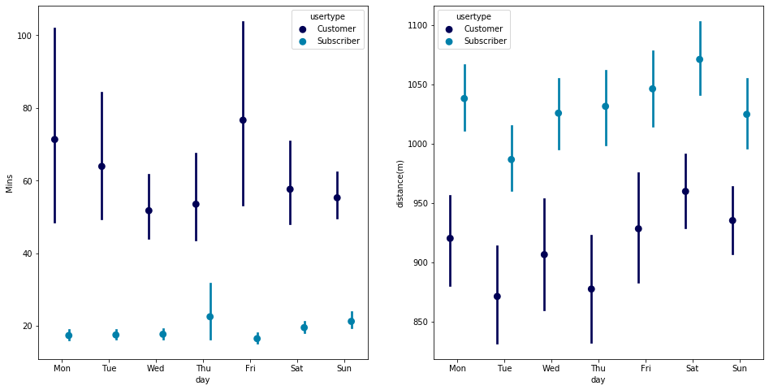

```python
fig, ax = plt.subplots(1,2, figsize = [16,8] )

sb.pointplot(data = trips, x = 'day', y = 'Mins', hue = 'usertype', dodge = 0.3, linestyles = "",  ax=ax[0], palette="ocean")
sb.pointplot(data = trips, x = 'day', y = 'distance(m)', hue = 'usertype', dodge = 0.3, linestyles = "", ax=ax[1], palette="ocean");
```

**Finding 19:** This graph shows that customers tend to have longer trip duration than subscribers, however, they also take lower distances. This suggests that the distance traveled are not positively corelated with the trip duration. This may be assigned to the fact that subscriber have more flexiblity and practtice with the bikes giving them the advantage of quick trips with long distances unlike the casual customers who may only use the bikes for fun.

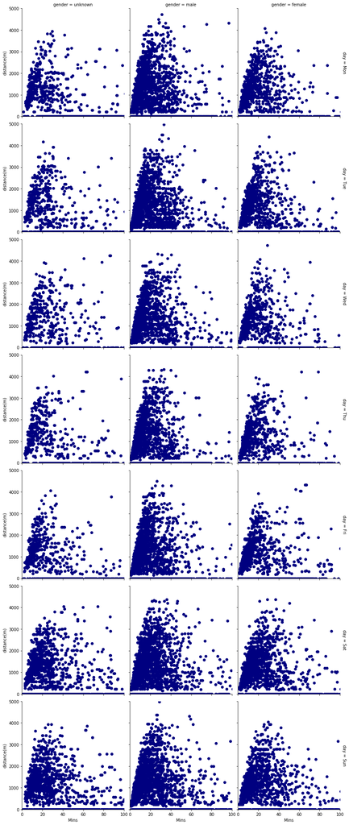

```python
g = sb.FacetGrid(data = trips, col = 'gender', row = 'day', height = 4,margin_titles = True, hue_kws=d)
g.map(plt.scatter, 'Mins', 'distance(m)');
g.set(xlim=(0, 100));
g.set(ylim=(0, 5000));
```

**Finding 20:** The scatter plots shows a positive relationship between the distance and the trip duration espically in the males group.

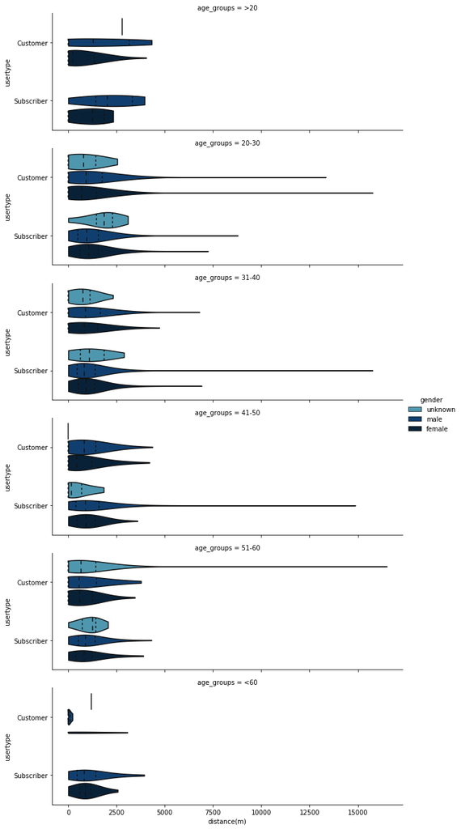

```python
g = sb.catplot(x="distance(m)", y="usertype",
                hue="gender", row="age_groups",
                data=trips[trips.usertype.notnull()], height=3, aspect=3, palette="ocean_r",
                kind="violin", dodge=True, cut=0, bw=1, inner ='quartile')
```

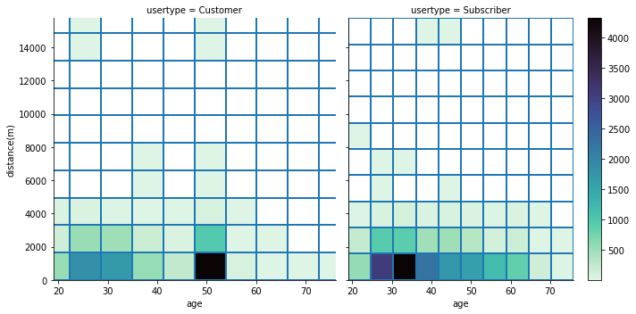

```python
g = sb.FacetGrid(data = trips, col = 'usertype', height = 5)
g.map(plt.hist2d, 'age','distance(m)',cmin=0.3,cmap = 'mako_r')
plt.colorbar();
```

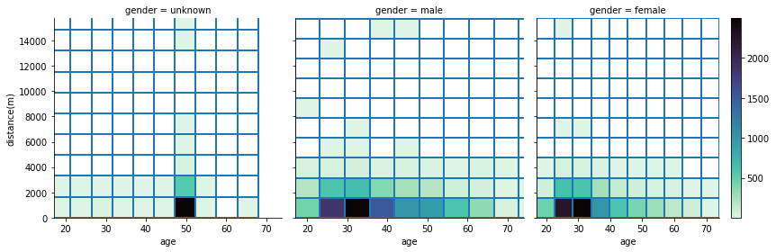

```python
g = sb.FacetGrid(data = trips, col = 'gender',height = 4)
g.map(plt.hist2d, 'age','distance(m)',cmin=0.1,cmap = 'mako_r');
plt.colorbar();
```

**Finding 23:** This heat map confirms the fact that users are clustered between mid 20s, 30s, and 50s. It also gives information about the genders of those clustered slices. So the ages of mid 20s are mostly females in which we previously showed that femalesare the least users of the bike systems. So that we can suggest that the cluster of mid 20s users comes in the third place after the big cluster of 50s users and 30s users.

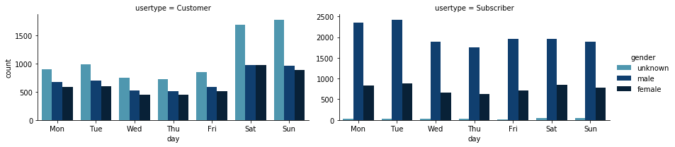

```python
graph = sb.catplot(data=trips, x='day', col="usertype", hue="gender", kind='count', sharey = False, height=3, aspect=2, palette="ocean_r");
```

**Finding 24:** This bar chart confirms the fact that most of the subscribers are males and females are the least users of the system. Also, it confirms that most of the overall casual users focus on weekends and subscribers are clustered more in the normal week days. However, it shows that distribution of these gendersand types of users on every week day in whichyou can notice a peak on Tuesday than any other day for subscribers and also on the used weekdays of casual users.

### The relationships observed in this part of the investigation and the features that strengthened each other in terms of looking at your feature(s) of interest

> This section was a further investigation of the previous two parts. The unobvious pattern was investigated and studied more effiecntly than the last parts. The data confirmed all the investigations in the previous sections and amplified the results and observations were made more clear and detalied. The general patterns are he same such as the day usage of the customers and subscribers which is inversed in the two groups. Also the age groups who clusters in the casual customers at 50s and in the subscribers at younger ages. The addetion of variables life distance and time to this variables showed the habits of the groups, thier abilities to travel, and thier extrems.

### Interesting or surprising interactions between features

> The relationship between the distance traveled and the trip duration was an intersting finding. As I thought as the first it should be always a positive corelation between distance and time. Howecer, the data showed that there are no obvious relation between the two variables espically between ages groups. After more investigation the data showed that that the distance and the time may have a negative relationship if we compar them relative to the customer type. So after magnifing all the results it showed that the general pattern of the relationship between distance and time is a postive relationship. However, when it comes to user type, the time travled by the subscribers can be less than the customers with the same distance. So the corellation between them may seem to be negative realtive to the two groups. However, in general it's not exactly like this.